# Fase 3.2: Creación de una Red neuronal optimizada Fine Tunning

**Integrantes:**

- José Villalta
- Daniel Collaguazo

**Fecha:** 22 de Octubre de 2024

**Actividad:** Implementación de una red neuronal con una face de optimización(fine-tuning).

## I. Importación de Librerías

Se importan las librerías necesarias para la creación y entrenamiento de la red neuronal. Entre ellas, se incluyen `tensorflow` y `keras` asi como tambien `GridSearchCV` para la respectivva optimización y lala definición del modelo

```python
import pandas as pd
import numpy as np
import matplotlib.pyplot as plt

from time import time
from datetime import datetime, timedelta
from sklearn.model_selection import ShuffleSplit, cross_val_score
from tensorflow.keras.models import Sequential
from tensorflow.keras.layers import Dense, Dropout
from scikeras.wrappers import KerasClassifier  # Usar SciKeras en lugar de KerasClassifier
import time
from sklearn import set_config
from time import time


from sklearn.model_selection import train_test_split
from scikeras.wrappers import KerasClassifier, KerasRegressor
from sklearn.model_selection import cross_val_score
from sklearn.model_selection import StratifiedKFold
from sklearn.model_selection import ShuffleSplit
from sklearn.model_selection import GridSearchCV
from keras.layers import Dropout
from keras.models import load_model

from sklearn.model_selection import train_test_split

from sklearn.impute import SimpleImputer
from sklearn.preprocessing import OneHotEncoder, StandardScaler, OrdinalEncoder, MinMaxScaler
from sklearn.compose import make_column_transformer, ColumnTransformer
from sklearn.pipeline import Pipeline
import pickle
import seaborn as sns
import copy

# Fine Tunnig
from imblearn.over_sampling import SMOTE
from collections import Counter
import pandas as pd
from sklearn.preprocessing import LabelEncoder


from sklearn import metrics
from sklearn.metrics import confusion_matrix
from sklearn.metrics import accuracy_score
from sklearn.metrics import precision_score
from sklearn.metrics import recall_score
from sklearn.metrics import f1_score



from sklearn.preprocessing import LabelEncoder

print("Módulos y clases importados")
```

```
Módulos y clases importados
```

```python
def cargarPipeline(nombreArchivo):
    with open(nombreArchivo+'.pickle', 'rb') as handle:
        pipe = pickle.load(handle)
    return pipe
```

## II. Carga y Preprocesamiento de Datos

Se carga el conjunto de datos previamente procesado en las fases anteriores. Aquí se ajustan las variables y se organizan en formato adecuado para ser utilizado por la red neuronal.

```python
dataframe = pd.read_csv("data.csv")
print('cantidad de observaciones (clientes): ',dataframe.shape[0])
print('cantidad de variables: ',dataframe.shape[1])
print(dataframe.shape)
dataframe.head()
```

```
cantidad de observaciones (clientes):  12330
cantidad de variables:  18
(12330, 18)
```

|  | Administrative | Administrative_Duration | Informational | Informational_Duration | ProductRelated | ProductRelated_Duration | BounceRates | ExitRates | PageValues | SpecialDay | Month | OperatingSystems | Browser | Region | TrafficType | VisitorType | Weekend | Revenue |
| --- | --- | --- | --- | --- | --- | --- | --- | --- | --- | --- | --- | --- | --- | --- | --- | --- | --- | --- |
| 0 | 0 | 0.0 | 0 | 0.0 | 1 | 0.000000 | 0.20 | 0.20 | 0.0 | 0.0 | Feb | 1 | 1 | 1 | 1 | Returning_Visitor | False | False |
| 1 | 0 | 0.0 | 0 | 0.0 | 2 | 64.000000 | 0.00 | 0.10 | 0.0 | 0.0 | Feb | 2 | 2 | 1 | 2 | Returning_Visitor | False | False |
| 2 | 0 | 0.0 | 0 | 0.0 | 1 | 0.000000 | 0.20 | 0.20 | 0.0 | 0.0 | Feb | 4 | 1 | 9 | 3 | Returning_Visitor | False | False |
| 3 | 0 | 0.0 | 0 | 0.0 | 2 | 2.666667 | 0.05 | 0.14 | 0.0 | 0.0 | Feb | 3 | 2 | 2 | 4 | Returning_Visitor | False | False |
| 4 | 0 | 0.0 | 0 | 0.0 | 10 | 627.500000 | 0.02 | 0.05 | 0.0 | 0.0 | Feb | 3 | 3 | 1 | 4 | Returning_Visitor | True | False |

```python
#Se modifica la variable de salida (de estudio): Revebue
dataframe['Revenue'] = dataframe['Revenue'].astype(int)
dataframe
```

|  | Administrative | Administrative_Duration | Informational | Informational_Duration | ProductRelated | ProductRelated_Duration | BounceRates | ExitRates | PageValues | SpecialDay | Month | OperatingSystems | Browser | Region | TrafficType | VisitorType | Weekend | Revenue |
| --- | --- | --- | --- | --- | --- | --- | --- | --- | --- | --- | --- | --- | --- | --- | --- | --- | --- | --- |
| 0 | 0 | 0.0 | 0 | 0.0 | 1 | 0.000000 | 0.200000 | 0.200000 | 0.000000 | 0.0 | Feb | 1 | 1 | 1 | 1 | Returning_Visitor | False | 0 |
| 1 | 0 | 0.0 | 0 | 0.0 | 2 | 64.000000 | 0.000000 | 0.100000 | 0.000000 | 0.0 | Feb | 2 | 2 | 1 | 2 | Returning_Visitor | False | 0 |
| 2 | 0 | 0.0 | 0 | 0.0 | 1 | 0.000000 | 0.200000 | 0.200000 | 0.000000 | 0.0 | Feb | 4 | 1 | 9 | 3 | Returning_Visitor | False | 0 |
| 3 | 0 | 0.0 | 0 | 0.0 | 2 | 2.666667 | 0.050000 | 0.140000 | 0.000000 | 0.0 | Feb | 3 | 2 | 2 | 4 | Returning_Visitor | False | 0 |
| 4 | 0 | 0.0 | 0 | 0.0 | 10 | 627.500000 | 0.020000 | 0.050000 | 0.000000 | 0.0 | Feb | 3 | 3 | 1 | 4 | Returning_Visitor | True | 0 |
| ... | ... | ... | ... | ... | ... | ... | ... | ... | ... | ... | ... | ... | ... | ... | ... | ... | ... | ... |
| 12325 | 3 | 145.0 | 0 | 0.0 | 53 | 1783.791667 | 0.007143 | 0.029031 | 12.241717 | 0.0 | Dec | 4 | 6 | 1 | 1 | Returning_Visitor | True | 0 |
| 12326 | 0 | 0.0 | 0 | 0.0 | 5 | 465.750000 | 0.000000 | 0.021333 | 0.000000 | 0.0 | Nov | 3 | 2 | 1 | 8 | Returning_Visitor | True | 0 |
| 12327 | 0 | 0.0 | 0 | 0.0 | 6 | 184.250000 | 0.083333 | 0.086667 | 0.000000 | 0.0 | Nov | 3 | 2 | 1 | 13 | Returning_Visitor | True | 0 |
| 12328 | 4 | 75.0 | 0 | 0.0 | 15 | 346.000000 | 0.000000 | 0.021053 | 0.000000 | 0.0 | Nov | 2 | 2 | 3 | 11 | Returning_Visitor | False | 0 |
| 12329 | 0 | 0.0 | 0 | 0.0 | 3 | 21.250000 | 0.000000 | 0.066667 | 0.000000 | 0.0 | Nov | 3 | 2 | 1 | 2 | New_Visitor | True | 0 |

12330 rows × 18 columns

```python
Y=dataframe['Revenue']
dataframe = dataframe.drop(columns=['Revenue'], axis=1)
print(dataframe.shape)
dataframe.head()
```

```
(12330, 17)
```

|  | Administrative | Administrative_Duration | Informational | Informational_Duration | ProductRelated | ProductRelated_Duration | BounceRates | ExitRates | PageValues | SpecialDay | Month | OperatingSystems | Browser | Region | TrafficType | VisitorType | Weekend |
| --- | --- | --- | --- | --- | --- | --- | --- | --- | --- | --- | --- | --- | --- | --- | --- | --- | --- |
| 0 | 0 | 0.0 | 0 | 0.0 | 1 | 0.000000 | 0.20 | 0.20 | 0.0 | 0.0 | Feb | 1 | 1 | 1 | 1 | Returning_Visitor | False |
| 1 | 0 | 0.0 | 0 | 0.0 | 2 | 64.000000 | 0.00 | 0.10 | 0.0 | 0.0 | Feb | 2 | 2 | 1 | 2 | Returning_Visitor | False |
| 2 | 0 | 0.0 | 0 | 0.0 | 1 | 0.000000 | 0.20 | 0.20 | 0.0 | 0.0 | Feb | 4 | 1 | 9 | 3 | Returning_Visitor | False |
| 3 | 0 | 0.0 | 0 | 0.0 | 2 | 2.666667 | 0.05 | 0.14 | 0.0 | 0.0 | Feb | 3 | 2 | 2 | 4 | Returning_Visitor | False |
| 4 | 0 | 0.0 | 0 | 0.0 | 10 | 627.500000 | 0.02 | 0.05 | 0.0 | 0.0 | Feb | 3 | 3 | 1 | 4 | Returning_Visitor | True |

```python
# Reemplazar los meses con valores numéricos
month_mapping = {
    'Jan': 1, 'Feb': 2, 'Mar': 3, 'Apr': 4, 'May': 5, 'June': 6,
    'Jul': 7, 'Aug': 8, 'Sep': 9, 'Oct': 10, 'Nov': 11, 'Dec': 12
}
dataframe['Month'] = dataframe['Month'].map(month_mapping)

# Usar LabelEncoder para convertir VisitorType a números
label_encoder = LabelEncoder()
dataframe['VisitorType'] = label_encoder.fit_transform(dataframe['VisitorType'])

dataframe.head()
```

|  | Administrative | Administrative_Duration | Informational | Informational_Duration | ProductRelated | ProductRelated_Duration | BounceRates | ExitRates | PageValues | SpecialDay | Month | OperatingSystems | Browser | Region | TrafficType | VisitorType | Weekend |
| --- | --- | --- | --- | --- | --- | --- | --- | --- | --- | --- | --- | --- | --- | --- | --- | --- | --- |
| 0 | 0 | 0.0 | 0 | 0.0 | 1 | 0.000000 | 0.20 | 0.20 | 0.0 | 0.0 | 2 | 1 | 1 | 1 | 1 | 2 | False |
| 1 | 0 | 0.0 | 0 | 0.0 | 2 | 64.000000 | 0.00 | 0.10 | 0.0 | 0.0 | 2 | 2 | 2 | 1 | 2 | 2 | False |
| 2 | 0 | 0.0 | 0 | 0.0 | 1 | 0.000000 | 0.20 | 0.20 | 0.0 | 0.0 | 2 | 4 | 1 | 9 | 3 | 2 | False |
| 3 | 0 | 0.0 | 0 | 0.0 | 2 | 2.666667 | 0.05 | 0.14 | 0.0 | 0.0 | 2 | 3 | 2 | 2 | 4 | 2 | False |
| 4 | 0 | 0.0 | 0 | 0.0 | 10 | 627.500000 | 0.02 | 0.05 | 0.0 | 0.0 | 2 | 3 | 3 | 1 | 4 | 2 | True |

## III. Normalización y balanceo de los datos

En esta sección, Separamos la variable de salida asi como SMOTE para el balanceo de los datos y tener una mejor información previa al entrenamiento.

```python
# División de datos en conjuntos de entrenamiento y prueba
X_train, X_test, Y_train, Y_test = train_test_split(dataframe, Y, test_size=0.2, random_state=42)

smote = SMOTE(sampling_strategy='minority')
X_resampled, y_resampled = smote.fit_resample(X_train, Y_train)
sample_size = 0.5  # O ajusta al tamaño que prefieras

# Tomar la muestra estratificada para mantener el balance de clases
X_sampled, _, y_sampled, _ = train_test_split(X_resampled, y_resampled,
                                              train_size=sample_size,
                                              stratify=y_resampled,
                                              random_state=42)
```

```
Distribución de clases antes del balanceo:
Revenue
0    10422
1     1908
Name: count, dtype: int64
Distribución de clases después del balanceo:
Revenue
0    8367
1    8367
Name: count, dtype: int64
```

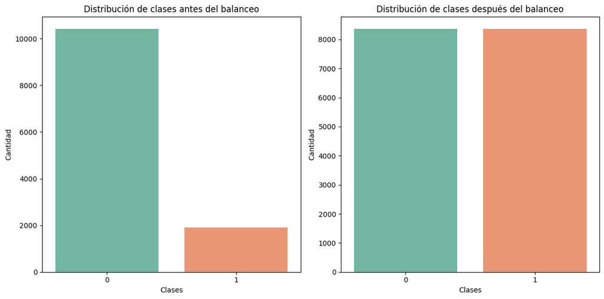

```python
# Contar el número de muestras por cada clase antes y después del balanceo
print("Distribución de clases antes del balanceo:")
print(pd.Series(Y).value_counts())
plt.figure(figsize=(12, 6))
plt.subplot(1, 2, 1)
sns.countplot(x=pd.Series(Y), palette="Set2")
plt.title("Distribución de clases antes del balanceo")
plt.xlabel("Clases")
plt.ylabel("Cantidad")

print("Distribución de clases después del balanceo:")
print(pd.Series(y_resampled).value_counts())
plt.subplot(1, 2, 2)
sns.countplot(x=pd.Series(y_resampled), palette="Set2")
plt.title("Distribución de clases después del balanceo")
plt.xlabel("Clases")
plt.ylabel("Cantidad")
plt.tight_layout()
plt.show()
```

```python
nombreArchivoPreprocesador='pipePreprocesadores'
pipe = cargarPipeline(nombreArchivoPreprocesador)
```

```python
#Se identifica la cantidad de variables para crear la capa de entrada de la red neuronal
nombrePrep='prepstandard'#prepcn, prepminmax, prepstandard
cantidadVariablesIndependientes = len(pipe.named_steps[nombrePrep].transformers_[0][2])
print("\nCantidad de variables después de preprocesamiento: ",cantidadVariablesIndependientes)
```

```
Cantidad de variables después de preprocesamiento:  66
```

## IV. Evaluación de modelo base: promedio de N experimentos

```python
#Se carga el pipeline que contiene solamente los pasos de preparación de datos
pipe=cargarPipeline('pipePreprocesadores')
X=copy.deepcopy(dataframe)

def build_model():
    model = Sequential()
    model.add(Dense(3, input_shape=(cantidadVariablesIndependientes,), activation='relu'))
    model.add(Dense(1, activation='sigmoid'))
    model.compile(loss='binary_crossentropy', optimizer='rmsprop', metrics=['accuracy'])
    return model

#El modelo se pasa como parámetro
estimator = KerasClassifier(build_fn=build_model, epochs=10, batch_size=50)  #KerasRegressor para problemas de regresión
pipe.steps.append(['modelNN',estimator])

#numFolds es la cantidad de Folds (conjuntos) para el entrenamiento del modelo
numFolds=5
#kfold es la configuración de validación K-Fold Cross-Validation
kfold = ShuffleSplit(n_splits=numFolds)

#n_jobs es para ocupar mas de un procesador. El parámetro -1 indica que se utilizarán todos los procesadores disponibles
cvs=cross_val_score(pipe, X_sampled, y_sampled, cv=kfold, n_jobs=-1, error_score="raise")
print("Scores:")# accuracy
for i in range(numFolds):
    print(cvs[i])
print("Accuracy de Modelo Base: ", cvs.mean())
accuracyModeloBase = cvs.mean()
```

```
Scores:
0.8649940262843488
0.8554360812425329
0.8626045400238949
0.8661887694145759
0.8327359617682198
Accuracy de Modelo Base:  0.8563918757467144
```

## V. Parámetros de compilación

En esta sección se define algunos parametros para la optimización

```python
#Función para convertir el tiempo de segundos al formato de días, horas, minutos y segundos.
def GetTime(gs_time):
    sec=timedelta(seconds=gs_time)
    d = datetime(1,1,1) + sec
    tiempoTotal=("%d días: %d horas: %d min: %d seg" % (d.day-1, d.hour, d.minute, d.second))
    return tiempoTotal
```

```python
pipe = cargarPipeline(nombreArchivoPreprocesador)
X = copy.deepcopy(dataframe)

def build_model():
    model = Sequential()
    model.add(Dense(3, input_shape=(cantidadVariablesIndependientes,), activation='relu'))
    model.add(Dense(1, activation='sigmoid'))
    model.compile(loss='binary_crossentropy', metrics=['acc'])
    return model

# Reducimos los valores a la mitad
batch_size = [2, 10, 40]  # Antes: [2, 5, 10, 20, 40, 80]
epochs = [5, 25, 50]      # Antes: [5, 10, 25, 50, 75, 100]
optimizer = ['RMSprop', 'Adam']

# Parámetros reducidos
parameters = {'modelNN__batch_size': batch_size,
              'modelNN__epochs': epochs,
              'modelNN__optimizer': optimizer}

estimator = KerasClassifier(model=build_model, verbose=0)

pipe.steps.append(['modelNN', estimator])

# GridSearchCV con los parámetros reducidos
tic = time()

grid_search = GridSearchCV(estimator=pipe, param_grid=parameters, scoring='accuracy', cv=5, n_jobs=-1, error_score='raise')

grid_result = grid_search.fit(X_sampled, y_sampled)

print(grid_result.best_params_)

gs_time = time() - tic
print('Tiempo en segundos: ', gs_time)
tiempoTotal = GetTime(gs_time)
print('Tiempo: ', tiempoTotal)

gs1 = grid_result
```

```
{'modelNN__batch_size': 40, 'modelNN__epochs': 50, 'modelNN__optimizer': 'RMSprop'}
Tiempo en segundos:  4697.315935373306
Tiempo:  0 días: 1 horas: 18 min: 17 seg
```

```python
estimator.get_params().keys()
```

```
dict_keys(['model', 'build_fn', 'warm_start', 'random_state', 'optimizer', 'loss', 'metrics', 'batch_size', 'validation_batch_size', 'verbose', 'callbacks', 'validation_split', 'shuffle', 'run_eagerly', 'epochs', 'class_weight'])
```

```python
print("Best: %f using %s" % (gs1.best_score_, gs1.best_params_))
```

```
Best: 0.879406 using {'modelNN__batch_size': 40, 'modelNN__epochs': 50, 'modelNN__optimizer': 'RMSprop'}
```

```python
means = gs1.cv_results_['mean_test_score']
stds = gs1.cv_results_['std_test_score']
params = gs1.cv_results_['params']
for mean, stdev, param in zip(means, stds, params):
    print("%f (%f) with: %r" % (mean, stdev, param))
```

```
0.854666 (0.009816) with: {'modelNN__batch_size': 2, 'modelNN__epochs': 5, 'modelNN__optimizer': 'RMSprop'}
0.857297 (0.008425) with: {'modelNN__batch_size': 2, 'modelNN__epochs': 5, 'modelNN__optimizer': 'Adam'}
0.867215 (0.010126) with: {'modelNN__batch_size': 2, 'modelNN__epochs': 25, 'modelNN__optimizer': 'RMSprop'}
0.876179 (0.008238) with: {'modelNN__batch_size': 2, 'modelNN__epochs': 25, 'modelNN__optimizer': 'Adam'}
0.877374 (0.005954) with: {'modelNN__batch_size': 2, 'modelNN__epochs': 50, 'modelNN__optimizer': 'RMSprop'}
0.874146 (0.010652) with: {'modelNN__batch_size': 2, 'modelNN__epochs': 50, 'modelNN__optimizer': 'Adam'}
0.859687 (0.005790) with: {'modelNN__batch_size': 10, 'modelNN__epochs': 5, 'modelNN__optimizer': 'RMSprop'}
0.850483 (0.010893) with: {'modelNN__batch_size': 10, 'modelNN__epochs': 5, 'modelNN__optimizer': 'Adam'}
0.870560 (0.012289) with: {'modelNN__batch_size': 10, 'modelNN__epochs': 25, 'modelNN__optimizer': 'RMSprop'}
0.874029 (0.008819) with: {'modelNN__batch_size': 10, 'modelNN__epochs': 25, 'modelNN__optimizer': 'Adam'}
0.878569 (0.007746) with: {'modelNN__batch_size': 10, 'modelNN__epochs': 50, 'modelNN__optimizer': 'RMSprop'}
0.877613 (0.007695) with: {'modelNN__batch_size': 10, 'modelNN__epochs': 50, 'modelNN__optimizer': 'Adam'}
0.817496 (0.014145) with: {'modelNN__batch_size': 40, 'modelNN__epochs': 5, 'modelNN__optimizer': 'RMSprop'}
0.818933 (0.008098) with: {'modelNN__batch_size': 40, 'modelNN__epochs': 5, 'modelNN__optimizer': 'Adam'}
0.866499 (0.011443) with: {'modelNN__batch_size': 40, 'modelNN__epochs': 25, 'modelNN__optimizer': 'RMSprop'}
0.868053 (0.004258) with: {'modelNN__batch_size': 40, 'modelNN__epochs': 25, 'modelNN__optimizer': 'Adam'}
0.879406 (0.009677) with: {'modelNN__batch_size': 40, 'modelNN__epochs': 50, 'modelNN__optimizer': 'RMSprop'}
0.876299 (0.005718) with: {'modelNN__batch_size': 40, 'modelNN__epochs': 50, 'modelNN__optimizer': 'Adam'}
```

## Densidad de las capas de neuronas y regularización de Dropout

Dentro de esta sección ajustamos la cantidad de desidad y el dropout en las capas

```python
pipe=cargarPipeline(nombreArchivoPreprocesador)
X=copy.deepcopy(dataframe)

def build_model(l1,l2,dr):
    model = Sequential()
    model.add(Dense(l1, input_shape=(cantidadVariablesIndependientes,), activation='relu'))
    model.add(Dropout(dr))
    model.add(Dense(l2, activation='relu'))
    model.add(Dropout(dr))
    model.add(Dense(1, activation='sigmoid'))
    model.compile(loss='binary_crossentropy', optimizer='RMSprop', metrics=['acc'])#RMSprop
    return model

l1=[16,32,64]
l2=[16,32,64]
dr=[0,0.2,0.35,0.5]

parameters = parameters = {'modelNN__l1':l1,
                           'modelNN__l2':l2,
                           'modelNN__dr':dr}

estimator = KerasClassifier(model=build_model, verbose=0, batch_size=40, epochs=50, l1=2, l2=2, dr=0.2)

pipe.steps.append(['modelNN',estimator])

tic = time()

grid_search = GridSearchCV(estimator=pipe, param_grid=parameters, scoring='accuracy', cv=5, n_jobs=-1)
grid_result = grid_search.fit(X_sampled, y_sampled)


gs_time1 = time() - tic
print('Tiempo en segundos: ',gs_time1)
tiempoTotal=GetTime(gs_time1)
print('Tiempo: ',tiempoTotal)

gs2=grid_result
```

```
Tiempo en segundos:  3435.17494058609
Tiempo:  0 días: 0 horas: 57 min: 15 seg
```

```python
print("Best: %f using %s" % (gs2.best_score_, gs2.best_params_))
```

```
Best: 0.897095 using {'modelNN__dr': 0.2, 'modelNN__l1': 64, 'modelNN__l2': 64}
```

```python
means = gs2.cv_results_['mean_test_score']
stds = gs2.cv_results_['std_test_score']
params = gs2.cv_results_['params']
for mean, stdev, param in zip(means, stds, params):
    print("%f (%f) with: %r" % (mean, stdev, param))
```

```
0.889087 (0.008426) with: {'modelNN__dr': 0, 'modelNN__l1': 16, 'modelNN__l2': 16}
0.890044 (0.007630) with: {'modelNN__dr': 0, 'modelNN__l1': 16, 'modelNN__l2': 32}
0.889327 (0.007728) with: {'modelNN__dr': 0, 'modelNN__l1': 16, 'modelNN__l2': 64}
0.889207 (0.007064) with: {'modelNN__dr': 0, 'modelNN__l1': 32, 'modelNN__l2': 16}
0.886457 (0.007696) with: {'modelNN__dr': 0, 'modelNN__l1': 32, 'modelNN__l2': 32}
0.888610 (0.006233) with: {'modelNN__dr': 0, 'modelNN__l1': 32, 'modelNN__l2': 64}
0.884666 (0.005529) with: {'modelNN__dr': 0, 'modelNN__l1': 64, 'modelNN__l2': 16}
0.883111 (0.009696) with: {'modelNN__dr': 0, 'modelNN__l1': 64, 'modelNN__l2': 32}
0.880600 (0.010052) with: {'modelNN__dr': 0, 'modelNN__l1': 64, 'modelNN__l2': 64}
0.891119 (0.008679) with: {'modelNN__dr': 0.2, 'modelNN__l1': 16, 'modelNN__l2': 16}
0.892195 (0.008035) with: {'modelNN__dr': 0.2, 'modelNN__l1': 16, 'modelNN__l2': 32}
0.895183 (0.008484) with: {'modelNN__dr': 0.2, 'modelNN__l1': 16, 'modelNN__l2': 64}
0.893510 (0.007976) with: {'modelNN__dr': 0.2, 'modelNN__l1': 32, 'modelNN__l2': 16}
0.894466 (0.004981) with: {'modelNN__dr': 0.2, 'modelNN__l1': 32, 'modelNN__l2': 32}
0.893748 (0.009325) with: {'modelNN__dr': 0.2, 'modelNN__l1': 32, 'modelNN__l2': 64}
0.895182 (0.006403) with: {'modelNN__dr': 0.2, 'modelNN__l1': 64, 'modelNN__l2': 16}
0.893868 (0.008239) with: {'modelNN__dr': 0.2, 'modelNN__l1': 64, 'modelNN__l2': 32}
0.897095 (0.006263) with: {'modelNN__dr': 0.2, 'modelNN__l1': 64, 'modelNN__l2': 64}
0.887055 (0.008588) with: {'modelNN__dr': 0.35, 'modelNN__l1': 16, 'modelNN__l2': 16}
0.889686 (0.005636) with: {'modelNN__dr': 0.35, 'modelNN__l1': 16, 'modelNN__l2': 32}
0.889804 (0.008791) with: {'modelNN__dr': 0.35, 'modelNN__l1': 16, 'modelNN__l2': 64}
0.893271 (0.006798) with: {'modelNN__dr': 0.35, 'modelNN__l1': 32, 'modelNN__l2': 16}
0.893391 (0.004322) with: {'modelNN__dr': 0.35, 'modelNN__l1': 32, 'modelNN__l2': 32}
0.894227 (0.006279) with: {'modelNN__dr': 0.35, 'modelNN__l1': 32, 'modelNN__l2': 64}
0.894227 (0.003912) with: {'modelNN__dr': 0.35, 'modelNN__l1': 64, 'modelNN__l2': 16}
0.894347 (0.005338) with: {'modelNN__dr': 0.35, 'modelNN__l1': 64, 'modelNN__l2': 32}
0.895063 (0.005992) with: {'modelNN__dr': 0.35, 'modelNN__l1': 64, 'modelNN__l2': 64}
0.881318 (0.008164) with: {'modelNN__dr': 0.5, 'modelNN__l1': 16, 'modelNN__l2': 16}
0.884067 (0.006401) with: {'modelNN__dr': 0.5, 'modelNN__l1': 16, 'modelNN__l2': 32}
0.882753 (0.006415) with: {'modelNN__dr': 0.5, 'modelNN__l1': 16, 'modelNN__l2': 64}
0.883231 (0.006279) with: {'modelNN__dr': 0.5, 'modelNN__l1': 32, 'modelNN__l2': 16}
0.887893 (0.006947) with: {'modelNN__dr': 0.5, 'modelNN__l1': 32, 'modelNN__l2': 32}
0.889088 (0.007663) with: {'modelNN__dr': 0.5, 'modelNN__l1': 32, 'modelNN__l2': 64}
0.888848 (0.005354) with: {'modelNN__dr': 0.5, 'modelNN__l1': 64, 'modelNN__l2': 16}
0.889087 (0.006728) with: {'modelNN__dr': 0.5, 'modelNN__l1': 64, 'modelNN__l2': 32}
0.891238 (0.007412) with: {'modelNN__dr': 0.5, 'modelNN__l1': 64, 'modelNN__l2': 64}
```

```python
cv_results= pd.DataFrame(gs2.cv_results_)
cv_results.head(3)
```

|  | mean_fit_time | std_fit_time | mean_score_time | std_score_time | param_modelNN__dr | param_modelNN__l1 | param_modelNN__l2 | params | split0_test_score | split1_test_score | split2_test_score | split3_test_score | split4_test_score | mean_test_score | std_test_score | rank_test_score |
| --- | --- | --- | --- | --- | --- | --- | --- | --- | --- | --- | --- | --- | --- | --- | --- | --- |
| 0 | 33.722886 | 0.511142 | 0.708591 | 0.211265 | 0.0 | 16 | 16 | {'modelNN__dr': 0, 'modelNN__l1': 16, 'modelNN... | 0.894863 | 0.896057 | 0.874477 | 0.884638 | 0.895397 | 0.889087 | 0.008426 | 24 |
| 1 | 35.221109 | 1.868822 | 0.375905 | 0.074697 | 0.0 | 16 | 32 | {'modelNN__dr': 0, 'modelNN__l1': 16, 'modelNN... | 0.894863 | 0.887694 | 0.876270 | 0.897788 | 0.893604 | 0.890044 | 0.007630 | 17 |
| 2 | 34.014388 | 1.543746 | 0.804572 | 0.205265 | 0.0 | 16 | 64 | {'modelNN__dr': 0, 'modelNN__l1': 16, 'modelNN... | 0.898447 | 0.884110 | 0.878661 | 0.887627 | 0.897788 | 0.889327 | 0.007728 | 20 |

## Presentación de resultados

Aqui presentamos los resultados de la optimización

```python
cv_results = cv_results.sort_values("mean_test_score", ascending=False)
cv_results=cv_results[["mean_test_score", "std_test_score",
            "param_modelNN__l1",
            "param_modelNN__l2"
            ]]
cv_results.head(3)
```

|  | mean_test_score | std_test_score | param_modelNN__l1 | param_modelNN__l2 |
| --- | --- | --- | --- | --- |
| 17 | 0.897095 | 0.006263 | 64 | 64 |
| 11 | 0.895183 | 0.008484 | 16 | 64 |
| 15 | 0.895182 | 0.006403 | 64 | 16 |

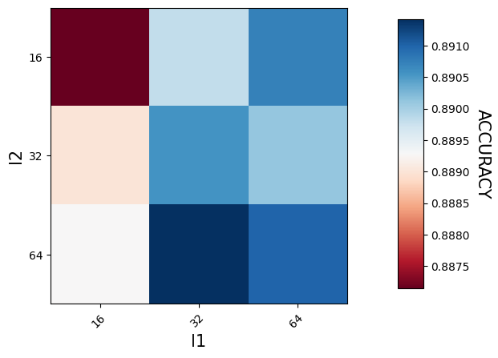

```python
def make_heatmap(ax, gs, is_sh=False, make_cbar=False, cmap='GnBu'):
    results=cv_results
    scores_matrix = pd.pivot_table(data=cv_results.sort_values('mean_test_score', ascending=False),
                                   index='param_modelNN__l2',
                                   columns='param_modelNN__l1',
                                   values='mean_test_score')
    im = ax.imshow(scores_matrix, cmap=cmap)
    z=results['mean_test_score']
    z_min, z_max = -np.abs(z).max(), np.abs(z).max()
    ax.set_xticks(np.arange(len(l1)))
    ax.set_xticklabels([x for x in l1])
    ax.set_xlabel('l1', fontsize=15)
    ax.set_yticks(np.arange(len(l2)))
    ax.set_yticklabels([x for x in l2])
    ax.set_ylabel('l2', fontsize=15)
    # Para girar las etiquetas de las marcas y establecer su alineación
    plt.setp(ax.get_xticklabels(), rotation=45, ha="right",
             rotation_mode="anchor")
    if make_cbar:
        fig.subplots_adjust(right=0.8)
        cbar_ax = fig.add_axes([0.85, 0.15, 0.05, 0.7])
        fig.colorbar(im, cax=cbar_ax)
        cbar_ax.set_ylabel('ACCURACY', rotation=-90, va="bottom",
                           fontsize=15)

fig, axes = plt.subplots(ncols=1, sharey=True)
ax2 = axes

make_heatmap(ax2, gs2, make_cbar=True, cmap='RdBu')
#Otros valores de colormaps: 'GnBu', 'RdBu', 'viridis', 'cividis'

#ax2.set_title('Tiempo = '+tiempoTotal, fontsize=15)
plt.show()
```

```python
pipe=cargarPipeline(nombreArchivoPreprocesador)


def build_model():
    model = Sequential()
    model.add(Dense(64, input_shape=(cantidadVariablesIndependientes,), activation='relu'))
    model.add(Dropout(0.35))
    model.add(Dense(4, activation='relu'))
    model.add(Dropout(0.35))
    model.add(Dense(1, activation='sigmoid'))
    model.compile(loss='binary_crossentropy', optimizer='RMSprop', metrics=['acc'])
    return model

estimator = KerasClassifier(model=build_model, verbose=0, batch_size=40, epochs=50)

pipe.steps.append(['modelNN',estimator])

numFolds=5
kfold = ShuffleSplit(n_splits=numFolds)

cvs=cross_val_score(pipe, X_sampled, y_sampled, cv=kfold, n_jobs=-1)
print("Scores:")# accuracy
for i in range(numFolds):
    print(cvs[i])
print("Media de scores: ", cvs.mean())
accuracyModeloOptimizado = cvs.mean()
```

```
Scores:
0.8936678614097969
0.8912783751493429
0.8841099163679809
0.8912783751493429
0.9032258064516129
Media de scores:  0.8927120669056153
```

```python
def guardarNN(model,nombreArchivo):
    print("Guardando Red Neuronal en Archivo")
    model.save(nombreArchivo+'.h5')
    print("Red Neuronal Grabada en Archivo")

def cargarNN(nombreArchivo):
    model = load_model(nombreArchivo+'.h5')
    print("Red Neuronal Cargada desde Archivo")
    return model
```

```python
pipe=cargarPipeline(nombreArchivoPreprocesador)
X=copy.deepcopy(dataframe)

def build_model():
    model = Sequential()
    model.add(Dense(64, input_shape=(cantidadVariablesIndependientes,), activation='relu'))
    model.add(Dropout(0.35))
    model.add(Dense(4, activation='relu'))
    model.add(Dropout(0.35))
    model.add(Dense(1, activation='sigmoid'))
    model.compile(loss='binary_crossentropy', optimizer='RMSprop', metrics=['acc'])
    return model

modeloOptimizado=build_model()

pipe.steps.append(['modelNN',modeloOptimizado])

X_train, X_test, y_train, y_test = train_test_split(X, Y, test_size = 0.2, random_state = 42)

pipe.fit(X_train, y_train, modelNN__batch_size=40, modelNN__epochs=50, modelNN__verbose=0)

guardarNN(pipe.named_steps['modelNN'],'modeloRedNeuronalOptimizada')

print('Modelo optimizado entrenado')
```

```
Guardando Red Neuronal en Archivo
Red Neuronal Grabada en Archivo
Modelo optimizado entrenado
```

```python
y_pred = (pipe.predict(X_test) > 0.5).astype("int32")
y_pred=y_pred.flatten()# de 2D a 1D

dataframeFinal=pd.DataFrame({'real':y_test, 'predicción': y_pred})

np.set_printoptions(formatter={'float': lambda X: "{0:0.0f}".format(X)})

dataframeFinal.tail(10)
```

```
78/78 ━━━━━━━━━━━━━━━━━━━━ 0s 2ms/step
```

|  | real | predicción |
| --- | --- | --- |
| 3307 | 1 | 1 |
| 3617 | 0 | 0 |
| 1891 | 1 | 0 |
| 2974 | 0 | 0 |
| 7134 | 0 | 0 |
| 295 | 1 | 1 |
| 3694 | 0 | 0 |
| 4974 | 0 | 0 |
| 10383 | 1 | 0 |
| 2611 | 0 | 0 |

```python
MAE=metrics.mean_absolute_error(y_test, y_pred)
MSE=metrics.mean_squared_error(y_test, y_pred)
RMSE=np.sqrt(metrics.mean_squared_error(y_test, y_pred))
accuracy=str(accuracy_score(y_test, y_pred))

accuracyModeloOptimizado= float(accuracy)

MAE=str(round(MAE, 4))
MSE=str(round(MSE, 4))
RMSE=str(round(RMSE, 4))

print('Mean Absolute Error (MAE):', MAE)
print('Mean Squared Error (MSE):', MSE)
print('Root Mean Squared Error (RMSE):', RMSE)
print('Accuracy: ' + accuracy)

print('Confusion_matrix:')
y_test_transformado = y_test
y_pred_transformado = y_pred

cm = confusion_matrix(y_test_transformado, y_pred_transformado)
print(cm)
tn, fp, fn, tp = confusion_matrix(y_test_transformado, y_pred_transformado).ravel()
print(tn,fp,fn,tp)

precision=precision_score(y_test_transformado, y_pred_transformado)
precision=str(round(precision, 4))
print('Precision: ',precision)

recall=recall_score(y_test_transformado, y_pred_transformado)
recall=str(round(recall, 4))
print('Recall: ',recall)

f1=f1_score(y_test_transformado, y_pred_transformado)
f1=str(round(f1, 4))
print('F1:',f1)
```

```
Mean Absolute Error (MAE): 0.1156
Mean Squared Error (MSE): 0.1156
Root Mean Squared Error (RMSE): 0.34
Accuracy: 0.8844282238442822
Confusion_matrix:
[[2012   43]
 [ 242  169]]
2012 43 242 169
Precision:  0.7972
Recall:  0.4112
F1: 0.5425
```

```python
def cargarRNN(nombreArchivo):
    model = load_model(nombreArchivo+'.keras')
    print("Red Neuronal Cargada desde Archivo")
    return model
```

```python
modeloBase=cargarRNN('RNBalanceadoOP')
modeloOptimizado=cargarNN('modeloRedNeuronalOptimizada')

accuracyModeloBase=float(str(0.8563918757467144))
accuracyModeloOptimizado=float(str(accuracyModeloOptimizado))
print('Accuracy Modelo Base: ',accuracyModeloBase)
print('Accuracy Modelo Optimizado: ',accuracyModeloOptimizado)
mejora=float(str(round((accuracyModeloOptimizado-accuracyModeloBase)*100,4)))

print('Mejora en %:',mejora)
```

```
WARNING:absl:Compiled the loaded model, but the compiled metrics have yet to be built. `model.compile_metrics` will be empty until you train or evaluate the model.
```

```
Red Neuronal Cargada desde Archivo
Red Neuronal Cargada desde Archivo
Accuracy Modelo Base:  0.8563918757467144
Accuracy Modelo Optimizado:  0.8844282238442822
Mejora en %: 2.8036
```

## Concluciones

Como conclusiones podemos decir que el modelo mejoro pero no de gran manera, aun asi se nota una mejora. El posible motivo por le cual no mejoro es por los pocos parametros de compilacion, ya que le pasaron la mitad de los parametros recomendados, esto debido a que la ejecucion tardaba mucho y Google Colab no permanecia mucho tiempo con una sesion activa. Aun asi el Acurracy mejoro de un 0.85 a un 0.88, mejoro en un 3%.